# 민주주의의 제도적 제약과 소득불평등이 난민 인정 및 수용에 미치는 조건적 효과

한국외국어대학교 경계너머 정례 발표

박상훈

sh.park.poli@gmail.com

강원대학교 통일강원연구원 선임연구원

March 19, 2026

## 규범적 기대와 경험적 현실의 괴리

### 규범적 기대: 난민 수용의 핵심 수호자

- 인권, 자유, 평등, 법치주의, 소수자 보호 가치의 내면화 (Ferejohn and Pasquino 2003)
- 1951년 난민협약 등 국제 난민 레짐 구축 주도 (Freeman 1995)
- 민주주의는 난민에게 우호적이고 포용적일 것이라는 당위적 기대 존재

### 경험적 현실: 난민 수용의 역설

- 난민 신청은 폭증하나, 실제 난민 인정률은 현저히 낮음 (Natter 2024)
- 심사 지연 및 인정 보류를 통한 우회적이고 사실상의 배제 전략 구사
- 유사한 외부 압력 속에서도 민주주의 국가 간 포용과 배제의 양상이 극단적으로  
  상이함

## 핵심 연구 질문

### 왜 규범적 기대와 달리 난민 인정에 배타적인가?

- **질문 1 (구조로서의 불평등과 위협 인식)**: 난민 정책 결정 과정에서 수용국  
  내부의 분배에 대한 **인식**과 **구조**의 정치적 반응성은 동일한가? 차별적인가?
- **질문 1 (불평등과 제도의 교차)**: 소득불평등이 촉발하는 경제적 압력 속에서,  
  민주주의의 핵심 제약(선거 책임성, 대중정당 제도화)은 난민 인정에  
  어떠한 영향을 미치는가?
- **질문 2 (체제 간 동학 차이)**: 민주주의와 권위주의라는 서로 다른 정치체제에 따라, 제도적 제약과 불평등의 조건적 효과는 어떻게 다르게 발현되는가?

## 기존 난민 수용 논의의 한계

### 전통적 경쟁 가설의 불충분성

- **경쟁 가설의 기대**: 불평등이 심화될수록 하위 계층의 경제적 위협 지각이 커져 이민자/난민 배제 선호가 강화됨 (Jørgensen and Thomsen 2016)
- **경험적 모순**: 개인 수준에서의 위협 지각과 달리, 거시적 국가 수준에서 소득불평등이 난민 배제로 일관되게 이어지지 않음 (Adamus and Grežo 2024)
- **미시-거시 간극**: 대중의 분산된 배타적 태도가 실제 국가 정책으로 전환되기 위해서는 이를 조직화하는 정치적/제도적 경로가 필수적임

## 불평등이 낳는 교차 압력 (Cross-Pressures)

### 대중의 배제 압력 vs 자본/엘리트의 개방 압력

- **대중의 배제적 압력**: 복지 자원 희소성 인식, 복지 쇼비니즘, 자격성 판단에 따른 조세/복지 혜택의 외부자 배제 요구 (Riaz 2024)
- **엘리트의 개방 압력**: 노동력 부족 해소, 인구 고령화 대응, 저비용 인력 확보를 통한 자본 소유자의 경제적 이득 추구 (Peters and Shin 2023)

**불평등의 역설적 역할**

통상적으로 경제적 어려움이나 직업 경쟁에 따른 위협으로 난민에 대한 반감이 증가한다는 미시적 주장과 달리, **소득 불평등이라는 구조적 여건은 노동 시장 유연화 등 엘리트의 이해관계와 맞물려 오히려 난민을 더 유입할 유인(개방 압력)을 창출함**

## 체제 비교: 난민 정책 결정 동학

### 어떤 경로가 정치적으로 조직화되는가의 문제

- **민주주의**: 유권자의 처벌 위협(강력한 제동)과 당원 중심의 선호 수집 메커니즘을 통해 내국인 우선주의가 정책으로 응집됨
- **권위주의**: 대중 선호를 수집하는 책임 기제 부재. 엘리트 협상, 외교적 이해관계, 정권 안정 논리에 의해 난민 정책 결정 (Tsourapas 2019; Betts 2021)
- 권위주의에서는 민주적 제동 장치가 작동하지 않거나 민주주의 수준의 제동 역할을 하지 못할 것

## 민주주의의 이중 제동 장치 1: 선거 책임성

### 사후적 처벌 위협을 통한 엘리트 개방 압력 억제

- **선거의 역할**: 주기적 선거를 통해 정치 지도자가 유권자에게 직접 책임지는  
  구조 형성 (Ashworth 2012; Svolik 2013)
- **제동 메커니즘**
  - 정치 엘리트가 난민 유입으로 경제적 이득을 기대하더라도, 대중의 배타적 여론을 거스를 경우 발생하는 선거 비용(Electoral Cost)을 두려워함
  - 투표권이 없는 난민(외부자)은 책임 회로에서 배제되므로 내국인 유권자 우선의 정책 결정이 고착화됨

## 민주주의의 이중 제동 장치 2: 대중정당 제도화

### 상시적 동원을 통한 배타적 선호의 정책화

- **대중정당의 역할**: 전국 및 지역 조직망, 사회단체와의 연계를 통해 당원 공동체의 선호를 상시로 수집하고 동원함 (Reuter 2022)
- **제동 메커니즘**
  - 정보 수집 및 정책 대변의 대상이 원천적으로 당원이 될 수 있는 시민권자로 국한됨
  - 현장 밀착 조직망이 강할수록 대중의 복지 쇼비니즘 프레임이 체계적으로 수집되어 배제적 정책으로 응집됨 (Vadlamannati 2020)

## 주효과 및 상호작용 가설 (민주주의 체제)

### 가설 1 & 2: 주효과 가설

- **가설 1 [+]**: 소득불평등이 심화될수록 자본/엘리트의 개방 압력이 대중의 반대보다 정책적 영향력이 커져 난민 인정률이 상승함
- **가설 2a, 2b [-]**: 선거 책임성과 대중정당 제도화 수준이 높을수록 배타적 선호가 조직화되어 난민 인정률이 감소함

### 가설 3: (상호작용 가설) 민주주의의 제도적 억제 작동

- 규범적으로 난민 친화적일 것이라고 생각되는 민주주의 정치체제는, **자국민에게 철저히 책임을 진다는 완벽한 제도적 제약성으로 인하여 소득 불평등 하에서 창출되는 난민 개방 압력을 흡수하고 차단하는 가장 강력한 억제 기제로 작동함**

## 분석 단위 및 핵심 변수

### 방출국-수용국-연도(Dyad-Year) 패널 데이터 분석

- **분석 범위**: 전 세계 국가쌍 간 패널 데이터  
  (최소주의적 접근법 기준 민주주의 vs 권위주의 하위 표본 분리)
- **종속 변수 (Y)**: 난민 인정률 (UNHCR 확정 결정 건수 중 인정 건수 비율, 로그 변환)
- **핵심 독립 변수 (X)**:
  - 소득불평등: 가처분소득 지니계수 (SWIID) (Solt 2016, 2020)
  - 선거 책임성: V-Dem 선거민주주의 지수 (EDI) (Teorell et al. 2019)
  - 대중정당 제도화: V-Party 대중 정당 조직화 지수 재조작화  
    (Reuter 2022; Park 2025)

## 주요 통제 변수

### 양자 관계 및 국가 수준 요인 통제

- **수용국 요인**: 1인당 GDP, 경제성장률, 기존 난민 유입 규모 통제
- **방출국 요인**: 인권 침해 점수 (Fariss 2014), 분쟁 경험 여부 (UCDP) 통제
- **양자 관계 요인**:
  - 지정학적 근접성 (UN 투표 이념거리) (Bailey et al. 2017)
  - 경제적 상호의존성 (양자 무역 비중)
  - 지리/안보 (국경 인접 여부, 동맹 여부) 통제

## 분석 모형 및 추정 전략

### 내생성 완화 및 오차 통제

- **분석 모형**:
  $$\begin{aligned}
  \ln(Y_{ijt}^{D}) =& \beta_0 + \beta_1(소득불평등)_{jt} + \beta_2(제도적\:\:제약)_{jt} \\
  &+ \beta_3(상호작용항)_{jt} + \delta Z_{it} + \eta W_{jt} + \gamma X_{ijt} \\
  &+ \tau_t + \epsilon_{ijt}
  \end{aligned}$$
- **추정 전략**
  - 역인과성 통제를 위해 모든 설명/통제변수에 1년 시차(1-year lag) 적용
  - 방출국-수용국 수준의 이원군집표준오차(Two-way Clustered SE)  
    적용으로 이분산성 및 계열상관 제어 (Cameron et al. 2011)
  - 연도 고정효과(Year FE) 포함을 통한 시간적 추세 통제

## 분석 결과

| 변수 | 민주주의 표본 | 권위주의 표본 |
| --- | --- | --- |
| 소득불평등 | **0.25** (0.08)** | 0.11 (0.09) |
| 선거 책임성 | **10.15* (4.88)** | 5.75 (8.23) |
| 대중정당 제도화 | -0.04 (0.14) | 0.25 (0.26) |
| 소득불평등 × 선거 책임성 | **-0.23* (0.11)** | -0.16 (0.15) |
| 소득불평등 × 대중정당 제도화 | -0.00 (0.00) | -0.01 (0.01) |
| 통제변수 및 연도고정효과 | 포함 | 포함 |
| 관측치 (N) | 8,260 | 972 |

비고: *** p < 0.001; ** p < 0.01; * p < 0.05. 괄호 안은 이원 군집표준오차. 통계적으로 유의미한 결과(음영 처리)는 **오직 민주주의 표본**에서만 관찰됨.

## 분석 결과 2: 상호작용 한계효과 (조건부 억제)

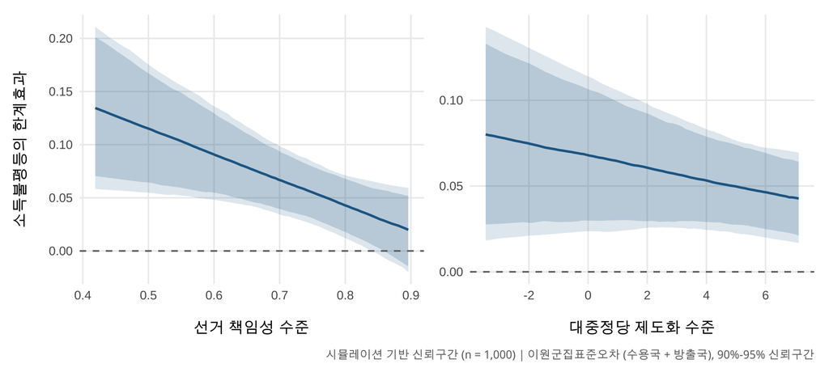

그림 1: 민주주의의 제도적 제약에 따른 소득불평등의 난민 인정률에 대한 한계효과 변화

## 분석 결과 3: 권위주의 체제의 무의미성

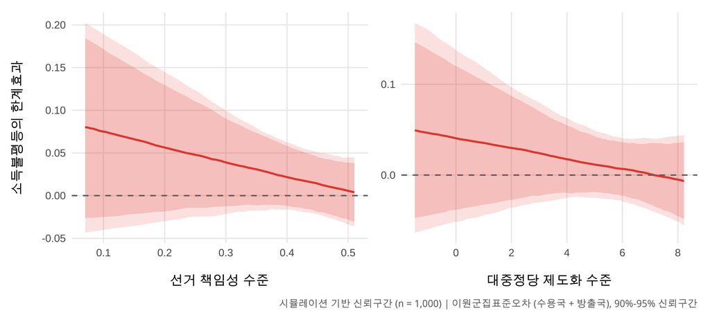

그림 2: 권위주의 제도적 제약에 따른 소득불평등의 난민 인정률에 대한 한계효과 변화

## 소득불평등-민주주의 사분면 국가 분포

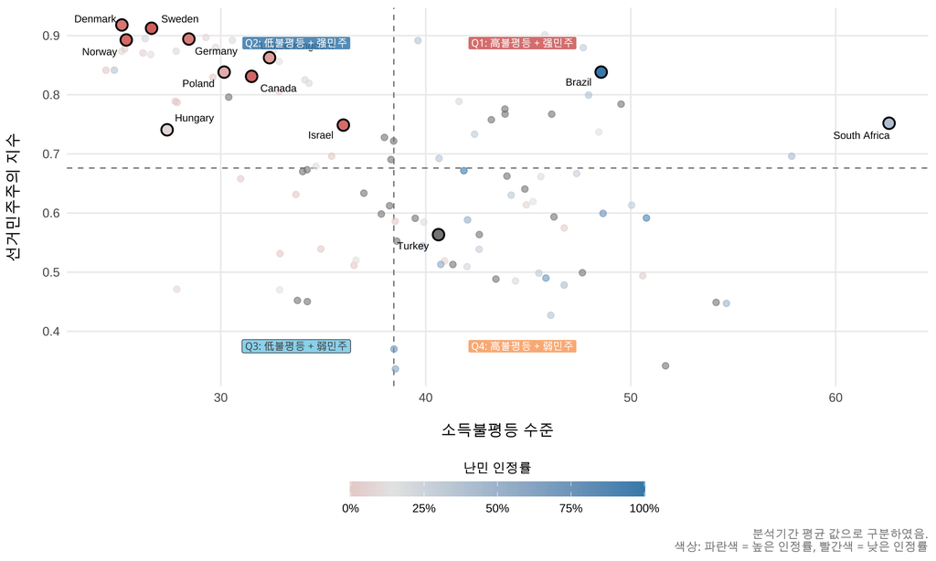

그림 3: 소득불평등과 민주주의 유형별 국가 분포와 난민 인정률

## 결론: 민주주의 난민 친화성 명제 재평가

### 규범적 통념의 전복과 체제 비대칭성

- **불평등의 역설적 역할**: 불평등 그 자체는 오히려 자본/엘리트의 이해관계를 통해  
  개방성을 높이는 매커니즘을 작동시킴
- **반응성의 양면성**: 민주주의 = 난민 친화적이라는 도식은 무조건적이지 않음.  
  선거 책임성과 당원 조직망은 투표권 있는 내부자를 향한 반응성이며, 이는 난민을 배제하는 강력한 제동 장치로 역전됨
- **체제 간 비대칭성**: 유사한 제도적 외형을 갖추었더라도, 권위주의에서는  
  민주적 장치가 작동하지 않아 온전히 엘리트의 지경학적/전략적 판단에 정책이 종속됨

## 정책적 함의 및 과제

### 이민 정책을 넘어선 구조적 연대 필요성

- **정치적 연합의 재구성**: 대중정당이 고도화된 환경에서는 하향식 엘리트  
  개방 정책이 한계를 지님. 당원 조직 내부에서부터 인도주의와 보완성을 결합하는 상향식(Bottom-up) 의제화가 요구됨
- **국내 분배 구조 개선의 선결**: 난민 수용 문제는 이민 정책 단독으로 해결될 수 없음. **복지, 노동, 주거 정책 등을 통한 대중의 불평등 완화 체감과 국내 분배 구조 개선이 병행되어야만 배타적 쇼비니즘을 잠재우고 포용을 위한 유의미한 정치적 연합 구축이 가능함**
- **국제적 부담 공유**: 수용국 민주주의가 직면한 선거 비용의 딜레마를 상쇄하기 위해 구속력 있는 국제적 비용 분담 메커니즘 고안이 시급함

[figure not shown]